# Chapter 2: Two variable regression analysis: Some basic ideas

### Meaning of the term **linear**

#### Linearity in the variables and linearity in parameters

$\beta_1 + \beta_2 \cdot X_i$ is linear in variable and linear in parameters. Linear in variables because $X_i$ has unit power. Linear in parameter because $\beta_1$ and $\beta_2$ have unit power.

$\beta_1 + \beta_2 \cdot X_i^2$ is non linear in variable but is linear in parameters. Non-linear in variables because $X_i^2$ has power of 2. Linear in parameter because $\beta_1$ and $\beta_2$ have unit power.

Both equations are linear and these equations will be used in the build up to the definition of the “linear” regression equation.

#### Exercise 2.1

What is the condition expectation function or the population regression function?

A: It is a function which tells how the mean or average of a population (Y) is related to the explanatory variables (X).

#### Exercise 2.2

What is the difference between the population and sample regression functions? Is this a distinction without difference?

A: The sample is supposed to represent the population.

#### Exercise 2.3

What is the role of the stochastic error term $u_i$ in regression analysis? What is the difference between the stochastic error term and the residual error $u_i$?

A: The stochastic error term is supposed to signify the amount of error in the explanatory variables. If the stochastic error is high it means that there are other terms which must be introduced to explain the dependent variable. The residual error on the other hand is the error caused by taking a sample of the population. Higher the residual error means the sample is not truly representitive of the population.

#### Exercise 2.4

Why do we need regression analysis? Why not simply use the mean value of the regressand as its best value?

A: In actual data we never get the mean of the regressand. We rather get samples which may be close or far away from the mean so it may be uncertain as to the sample value. Regression analysis is required to estimate to some degree the closeness of the data to the population.

#### Exercise 2.5

What do we mean by a linear regression model?

A: A model which may be linear or non-linear in variable but strictly linear in parameters is a linear regression model. It explains the dependent variable using explanatory variables with linear parameters.

#### Exercise 2.6

Determine whether the following models are linear in the parameters or the variables or both. Which of these models are linear regression models?

| Model | Descriptive title |
| --- | --- |
| a. $Y_i = \beta_1 + \beta_2 (1/X_i) + u_i$ | Reciprocal |
| b. $Y_i = \beta_1 + \beta_2 ln X_i + u_i$ | Semilogarithmic |
| c. $ln Y_i = \beta_1 + \beta_2 X_i + u_i$ | Inverse semilogarithmic |
| d. $ln Y_i = ln \beta_1 + \beta_2 ln X_i + u_i$ | Logarithmic or double logarithmic |
| e. $ln Y_i = \beta_1 - \beta_2 (1/X_i) + u_i$ | Logarithmic reciprocal |

A: (a) is linear in the parameters and non-linear in the variables  
(b) is linear in the parameters and non-linear in the variables  
(c) is linear in the parameters and non-linear in the variables  
(d) is non-linear in the parameters and non-linear in the variables. Transforming $\alpha = ln \beta_1$ will make the equation linear  
(e) is linear in the parameters and non-linear in the variables

#### Exercise 2.7

Are the following models linear regression models? Why or why not?

1. $Y_i = e^{\beta_1 + \beta_2 X_i + u_i}$
2. $Y_i = \frac{1}{1+e^{\beta_1 + \beta_2 X_i + u_i}}$
3. $ln Y_i = \beta_1 + \beta_2 (1/X_i) + u_i$
4. $Y_i = \beta_1+ (0.75 - \beta_1)e^{-\beta_2(X_i - 2)} + u_i$
5. $Y_i = \beta_1 + \beta_2^3 X_i + u_i$

A: (a) is linear (b) is linear. See the solutions manual for logit transformation (c) is linear (d) is non-linear (e) is non-linear

#### Exercise 2.8

What is meant by an intrinsically linear regression model? If $\beta_2$ in exercise 2.7d were 0.8 would it be a linear or nonlinear regression model?

A: A model which can be made linear in the paramters is called intrinsically linear regression model. If we put $\beta_2$ as 0.8 in exercise 2.7d we get a linear regression model

$Y_i = \beta_1+ (0.75 - \beta_1)e^{-0.8(X_i - 2)} + u_i$

#### Exercise 2.9

Consider the following non-stochastic models (i.e. models without the stochastic error term). Are they linear regression models? If not, is it possible, by suitable algebraic manipulations, to convert them into linear models?

1. $Y_i = \frac{1}{\beta_1 + \beta_2 X_i}$
2. $Y_i = \frac{X_i}{\beta_1 + \beta_2 X_i}$
3. $Y_i = \frac{1}{1+ e^{-\beta_1 - \beta_2 X_i}}$

A: See the solutions manual for explanation of how the transformations have been done

#### Exercise 2.10

You are given a scattergram in Figure 2.7 along with the regression line. What general conclusion do you draw from this diagram? Is the regression line sketched in the digram a population regression line or the sample regression line?

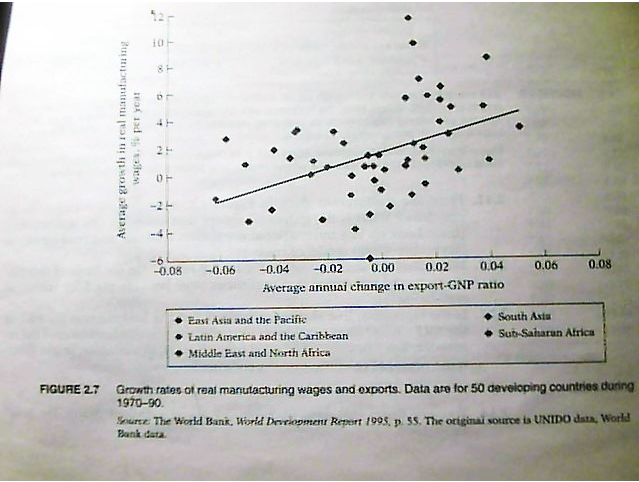

A: This is a sample regression line as it shows the wages growth with exports for 50 developing countries. It shows that a +ve or -ve change in GNP results in a +ve or -ve growth in wages.

#### Exercise 2.11

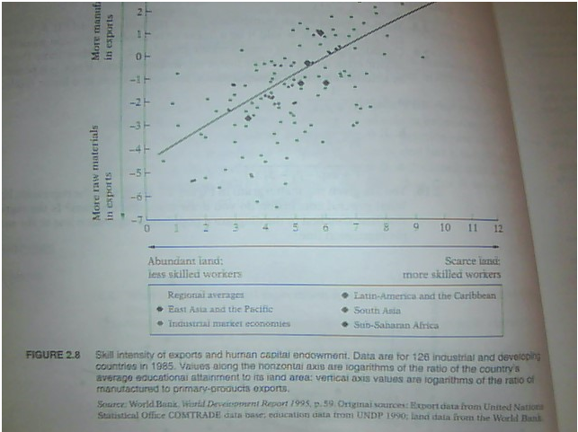

From the scattergram given in Figure 2.8, what general conclusions do you draw? What is the economic theory that underlies this scattergram? (Hint: Look up any international economics textbook and read up on the Heckscher-Ohlin model of trade)

A: I dont understand this figure frankly speaking.

#### Exercise 2.12

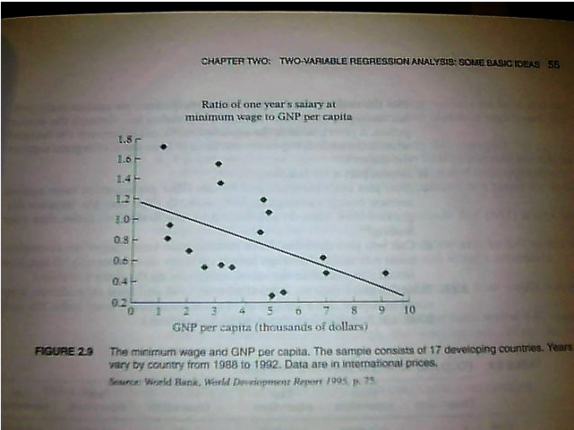

What does the scattergram in Fig 2.9 reveal? On the basis of this diagram, would you argue that minimum wage laws are good for economic well-being?

A: Higher the minimum wage ratio shows a lower GNP. It suggests that minimum wage laws are not good for developing countries.

#### Exercise 2.13

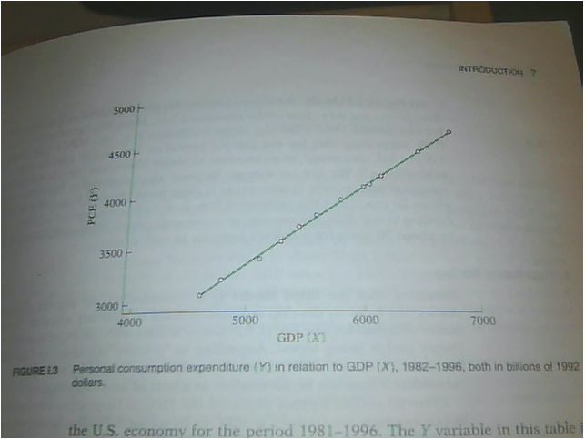

Is the regression line shown in figure 1.3 of the Introduction to PRF or the SRF. Why? How would you interpret the scatterpoints around the regression line? Beside GDP, what other factors, or variables, might determine personal consumption expenditure?

A: Its an SRF as it is a sample based on 15 years of observations. Personal consumption may be affected by the wealth or number of family members etc.

#### Exercise 2.14

You are given the data in Table 2.7 for the United States for years 1980-1996.

1. Plot the male civilian labor force participation against the male civilian unemployment rate. Eyeball a regression line through scatter points. A priori, what is the expected relationship between the two and what is the underlying economic theory? Does the scattergram support the theory?
2. Repeat part a. for females.
3. Now plot both the male and female labor participation rates against average hourly earnings (in 1982 dollars). (You may use seperate diagrams). Now what do you find? And how would you rationalize the finding?
4. Can you plot the labor force participation rate against the unemployment rate and the average hourly earnings simultaneously? If not how would you verbalize the relationship among the three variables?

#### a. Plot the male civilian labor force participation against the male civilian unemployment rate. Eyeball a regression line through scatter points. A priori, what is the expected relationship between the two and what is the underlying economic theory? Does the scattergram support the theory?

```r
laborUnempl <- read.table("https://raw.githubusercontent.com/cablegui/Econometrics/master/OriginalData/Table%202.7.txt", skip = 9, header = TRUE)

head(laborUnempl)
```

```
##   YEAR CLFPRM CLFPRF UNRM UNRF AHE82  AHE
## 1 1980   77.4   51.5  6.9  7.4  7.78 6.66
## 2 1981   77.0   52.1  7.4  7.9  7.69 7.25
## 3 1982   76.6   52.6  9.9  9.4  7.68 7.68
## 4 1983   76.4   52.9  9.9  9.2  7.79 8.02
## 5 1984   76.4   53.6  7.4  7.6  7.80 8.32
## 6 1985   76.3   54.5  7.0  7.4  7.77 8.57
```

```r
tail(laborUnempl)
```

```
##    YEAR CLFPRM CLFPRF UNRM UNRF AHE82   AHE
## 12 1991   75.8   57.4  7.2  6.4  7.45 10.32
## 13 1992   75.8   57.8  7.9  7.0  7.41 10.57
## 14 1993   75.4   57.9  7.2  6.6  7.39 10.83
## 15 1994   75.1   58.8  6.2  6.0  7.40 11.12
## 16 1995   75.0   58.9  5.6  5.6  7.40 11.44
## 17 1996   74.9   59.3  5.4  5.4  7.43 11.82
```

Table 2.7: Labor Force Participation Data

- Civilian Labor Force Participation Rate, Male (CLFPRM, %)
- Civilian Labor Force Participation Rate, Female (CLFPRF, %)
- Civilian Unemployment Rate, Male (UNRM, %)
- Civilian Unemployment Rate, Female (UNRF, %)
- Average Hourly Earnings (AHE82, 1982 $)
- Average Hourly Earnings (AHE, Current $)

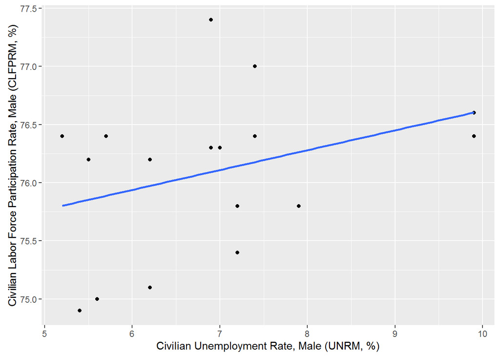

```r
require(ggplot2)
p <- ggplot(laborUnempl, aes(x=UNRM, y=CLFPRM)) +
  geom_point() +
  geom_smooth(method="lm", se=FALSE)+
  xlab("Civilian Unemployment Rate, Male (UNRM, %)") +
  ylab("Civilian Labor Force Participation Rate, Male (CLFPRM, %)")

p
```

```r
t <- lm(CLFPRM~UNRM, data=laborUnempl)

coef(t)
```

```
## (Intercept)        UNRM
##  74.9149621   0.1706012
```

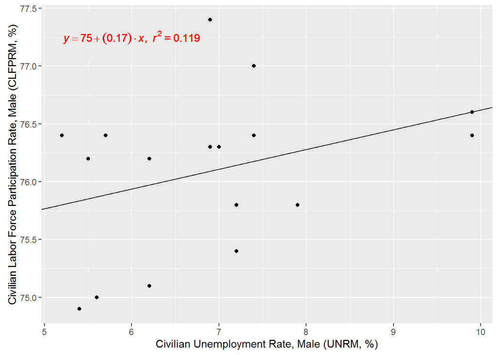

```r
# A cool function for placing math anotations on ggplots
# http://stackoverflow.com/questions/7549694/ggplot2-adding-regression-line-equation-and-r2-on-graph
# See the ?plotmath for help on how to write equations as the language is not Latex


lm_eqn <- function(df){
  eq <- substitute(italic(y) == a + (b)%.%italic(x)*","~~italic(r)^2~"="~r2,
                   list(a = format(coef(df)[1], digits = 2),
                        b = format(coef(df)[2], digits = 2),
                        r2 = format(summary(df)$r.squared, digits = 3)))
  as.character(as.expression(eq));
  }

p2 <- ggplot(laborUnempl, aes(x=UNRM, y=CLFPRM)) +
  geom_point() +
  geom_abline(slope = t$coefficients[2], intercept = t$coefficients[1]) +
  geom_text(x=6, y=77.25, label = lm_eqn(t), parse=TRUE, col="red") +
  xlab("Civilian Unemployment Rate, Male (UNRM, %)") +
  ylab("Civilian Labor Force Participation Rate, Male (CLFPRM, %)")

p2
```

A: Generally shows that as unemployment rate increases more people participate in the labour work force.

#### b. Repeat part a. for females.

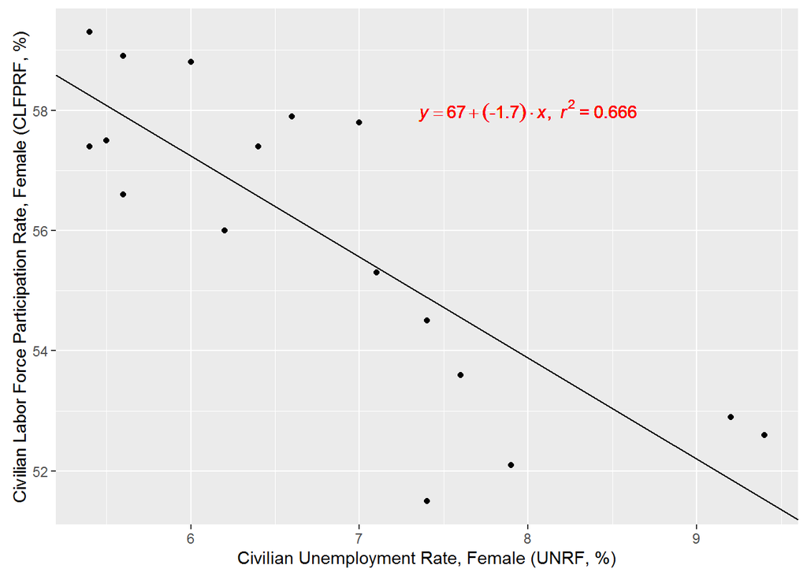

```r
t <- lm(CLFPRF~UNRF, data=laborUnempl)

p3 <- ggplot(laborUnempl, aes(x=UNRF, y=CLFPRF)) +
  geom_point() +
  geom_abline(slope = t$coefficients[2], intercept = t$coefficients[1]) +
  geom_text(x=8, y=58, label = lm_eqn(t), parse=TRUE, col="red") +
  xlab("Civilian Unemployment Rate, Female (UNRF, %)") +
  ylab("Civilian Labor Force Participation Rate, Female (CLFPRF, %)")

p3
```

A: Its quite opposite for females as its seen that female participation in the work force reduces as the unemployment rate increases

#### c. Now plot both the male and female labor participation rates against average hourly earnings (in 1982 dollars). (You may use seperate diagrams). Now what do you find? And how would you rationalize the finding?

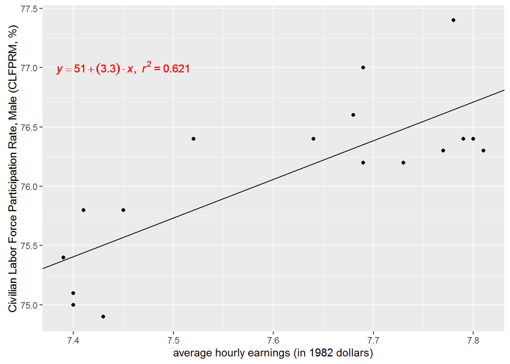

```r
t <- lm(CLFPRM~AHE82, data=laborUnempl)

ggplot(laborUnempl) +
  geom_point(aes(x=AHE82, y=CLFPRM)) +
  geom_abline(slope = t$coefficients[2], intercept = t$coefficients[1]) +
  geom_text(x=7.45, y=77, label = lm_eqn(t), parse=TRUE, col="red") +
  xlab("average hourly earnings (in 1982 dollars)") +
  ylab("Civilian Labor Force Participation Rate, Male (CLFPRM, %)")
```

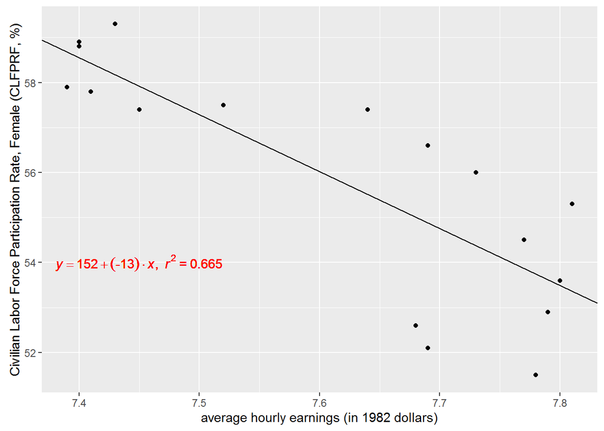

```r
t <- lm(CLFPRF~AHE82, data=laborUnempl)

ggplot(laborUnempl) +
  geom_point(aes(x=AHE82, y=CLFPRF)) +
  geom_abline(slope = t$coefficients[2], intercept = t$coefficients[1]) +
  geom_text(x=7.45, y=54, label = lm_eqn(t), parse=TRUE, col="red") +
  xlab("average hourly earnings (in 1982 dollars)") +
  ylab("Civilian Labor Force Participation Rate, Female (CLFPRF, %)")
```

A: It suggests that males tend to increase in participation when the average hourly earnings increase. Females decrease probably during this time there is no need for double income.

#### d. Can you plot the labor force participation rate against the unemployment rate and the average hourly earnings simultaneously? If not how would you verbalize the relationship among the three variables?

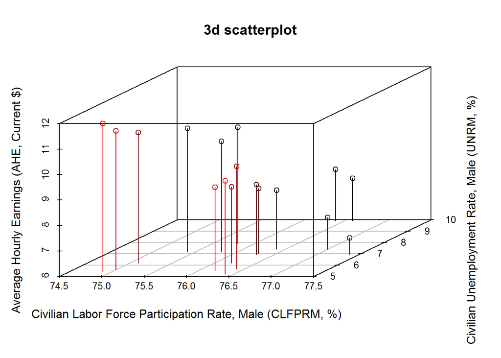

```r
require(scatterplot3d)
scatterplot3d(laborUnempl$CLFPRM, laborUnempl$UNRM, laborUnempl$AHE, main = "3d scatterplot",
              xlab="Civilian Labor Force Participation Rate, Male (CLFPRM, %)",
              ylab="Civilian Unemployment Rate, Male (UNRM, %)",
              zlab="Average Hourly Earnings (AHE, Current $)",highlight.3d = TRUE, type="h")
```

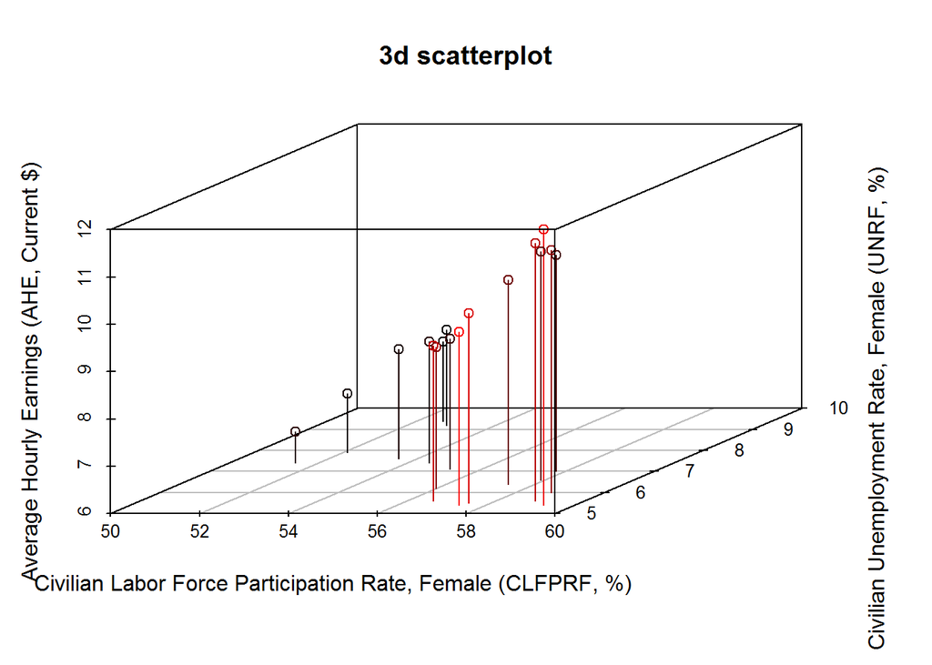

```r
scatterplot3d(laborUnempl$CLFPRF, laborUnempl$UNRF, laborUnempl$AHE, main = "3d scatterplot",
              xlab="Civilian Labor Force Participation Rate, Female (CLFPRF, %)",
              ylab="Civilian Unemployment Rate, Female (UNRF, %)",
              zlab="Average Hourly Earnings (AHE, Current $)", ,highlight.3d = TRUE, type="h")
```

#### Exercise 2.15

Table 2.8 gives data on expenditure on food and total expenditure, measured in rupees, for a sample of 55 rural households from India. (In early 2000 a U.S. dollar was about 40 Indian rupees)

1. Plot the data using the vertical axis for expenditure on food and the horizontal axis for total expenditure, and sketch a regression line through the scatterpoints.
2. What broad conclusions can you draw from this example?
3. A priori, would you expect expenditure on food to increase linearly as total expenditure increases regardless of the level of total expenditure? Why or why not? You can use total expenditure as a proxy for total income.

```r
foodVerTotExpen <- read.table("https://raw.githubusercontent.com/cablegui/Econometrics/master/OriginalData/Table%202.8.txt", skip=3, col.names = c("obs",   "FOODEXP",  "TOTALEXP"))

head(foodVerTotExpen)
```

```
##   obs FOODEXP TOTALEXP
## 1   1     217      382
## 2   2     196      388
## 3   3     303      391
## 4   4     270      415
## 5   5     325      456
## 6   6     260      460
```

```r
tail(foodVerTotExpen)
```

```
##    obs FOODEXP TOTALEXP
## 50  50     410      775
## 51  51     380      785
## 52  52     610      788
## 53  53     530      790
## 54  54     360      795
## 55  55     305      801
```

Table 2.8 Food and total expenditure (rupees)

#### a. Plot the data using the vertical axis for expenditure on food and the horizontal axis for total expenditure, and sketch a regression line through the scatterpoints.

```r
t <- lm(foodVerTotExpen$FOODEXP ~ foodVerTotExpen$TOTALEXP)

coef(t)
```

```
##              (Intercept) foodVerTotExpen$TOTALEXP
##               94.2087774                0.4368088
```

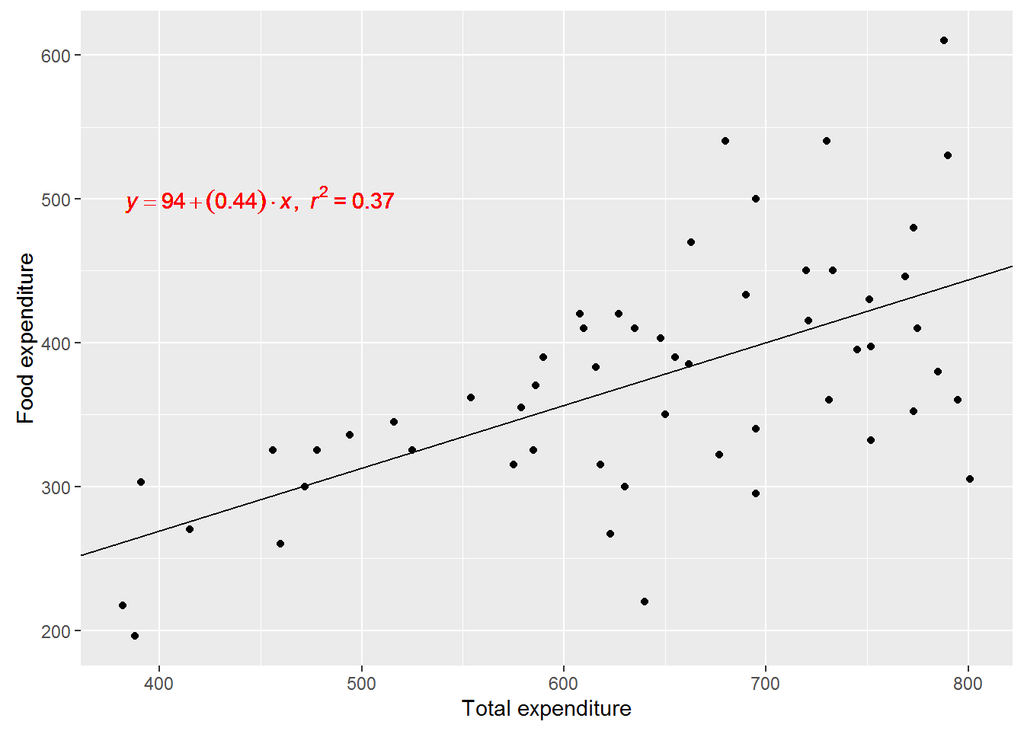

```r
p <- ggplot(foodVerTotExpen, aes(x=TOTALEXP, y=FOODEXP)) +
  geom_point() +
  geom_abline(slope = t$coefficients[2], intercept = t$coefficients[1]) +
  geom_text(x=450, y=500, label = lm_eqn(t), parse=TRUE, col="red") +
  xlab("Total expenditure") +
  ylab("Food expenditure")

p
```

#### b. What broad conclusions can you draw from this example?

A: Food expense generally increases as the total expense increases

#### c. A priori, would you expect expenditure on food to increase linearly as total expenditure increases regardless of the level of total expenditure? Why or why not? You can use total expenditure as a proxy for total income.

A: There are several factors which could make the food increase to be linear with total expenditure. For example if the household has more people then total expense increase and so will food expense. But if we consider that the people within a household count remains the same then the food expense should generally not change as the total expense increases.

#### Exercise 2.16

Table 2.9 gives data on mean Scholastic Aptitude Test (SAT) scores for college-bound seniors for 1967-1990.

1. Use the horizontal axis for years and the vertical axis for SAT scores to plot the verbal and math scores for males and females separately.
2. What general conclusions can you draw?
3. Knowing the verbal scores of males and females, how would you go about predicting their math scores?
4. Plot the female verbal SAT score against the male verbal SAT score. Sketch a regression line through the scatterpoints. What do you observe?

```r
maleFemaleSATscores <- read.table("https://raw.githubusercontent.com/cablegui/Econometrics/master/OriginalData/T2.9.txt", skip = 7, col.names=c("YEAR","VERBAL_MALES","VERBAL_FEMALES","VERBAL_TOTAL","MATH_MALES","MATH_FEMALES","MATH_TOTAL"))

head(maleFemaleSATscores)
```

```
##   YEAR VERBAL_MALES VERBAL_FEMALES VERBAL_TOTAL MATH_MALES MATH_FEMALES
## 1 1967          463            468          466        514          467
## 2 1968          464            466          466        512          470
## 3 1969          459            466          463        513          470
## 4 1970          459            461          460        509          465
## 5 1971          454            457          455        507          466
## 6 1972          454            452          453        505          461
##   MATH_TOTAL
## 1        492
## 2        492
## 3        493
## 4        488
## 5        488
## 6        484
```

```r
tail(maleFemaleSATscores)
```

```
##    YEAR VERBAL_MALES VERBAL_FEMALES VERBAL_TOTAL MATH_MALES MATH_FEMALES
## 19 1985          437            425          431        499          452
## 20 1986          437            426          431        501          451
## 21 1987          435            425          430        500          453
## 22 1988          435            422          428        498          455
## 23 1989          434            421          427        500          454
## 24 1990          429            419          424        499          455
##    MATH_TOTAL
## 19        475
## 20        475
## 21        476
## 22        476
## 23        476
## 24        476
```

Table 2.9 - Mean Scholastic Aptitude Test Scores for College-Bound Seniors, 1967 - 1990

#### a. Use the horizontal axis for years and the vertical axis for SAT scores to plot the verbal and math scores for males and females separately.

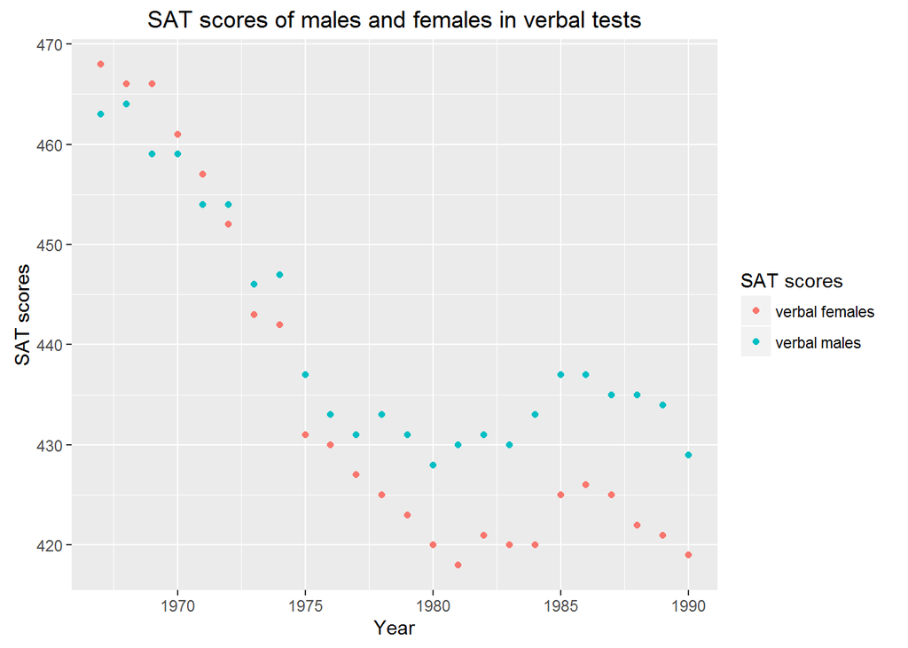

```r
ggplot(maleFemaleSATscores, aes(x=YEAR))+
  geom_point(aes(y=VERBAL_MALES,col="verbal males"))+
  geom_point(aes(y=VERBAL_FEMALES,col="verbal females")) +
  labs(colour="SAT scores")+ #Use labs(aesthetic= "name you want for legend"); where aesthetic can be linetype or shape or colour
  ylab("SAT scores") + xlab("Year") + ggtitle("SAT scores of males and females in verbal tests")
```

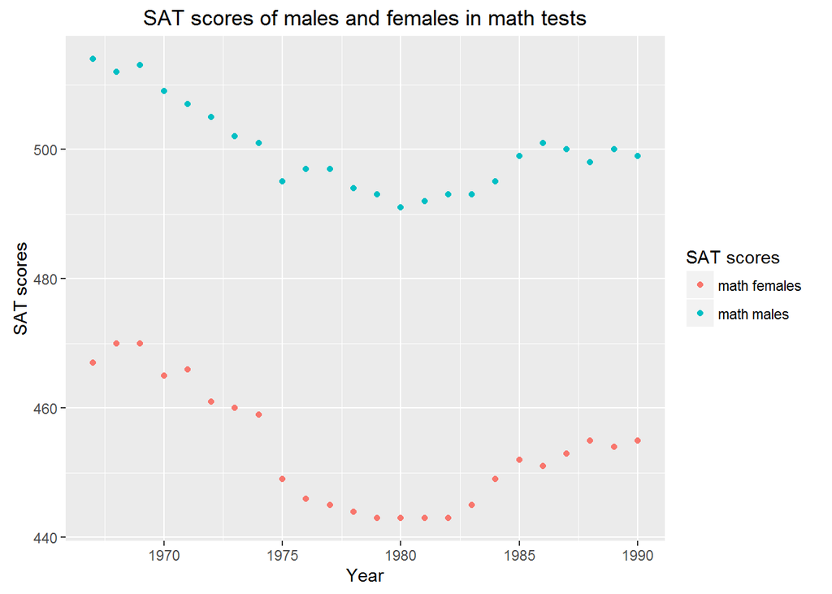

```r
ggplot(maleFemaleSATscores, aes(x=YEAR))+
  geom_point(aes(y=MATH_MALES,col="math males"))+
  geom_point(aes(y=MATH_FEMALES,col="math females")) +
  labs(colour="SAT scores")+ #Use labs(aesthetic= "name you want for legend"); where aesthetic can be linetype or shape or colour
  ylab("SAT scores") + xlab("Year") + ggtitle("SAT scores of males and females in math tests")
```

#### b. What general conclusions can you draw?

A: The SAT scores for males and females are trending downward with time.

3. Knowing the verbal scores of males and females, how would you go about predicting their math scores?

```r
t <- lm(maleFemaleSATscores$VERBAL_MALES ~ maleFemaleSATscores$MATH_MALES)

coef(t)
```

```
##                    (Intercept) maleFemaleSATscores$MATH_MALES
##                    -380.478856                       1.641791
```

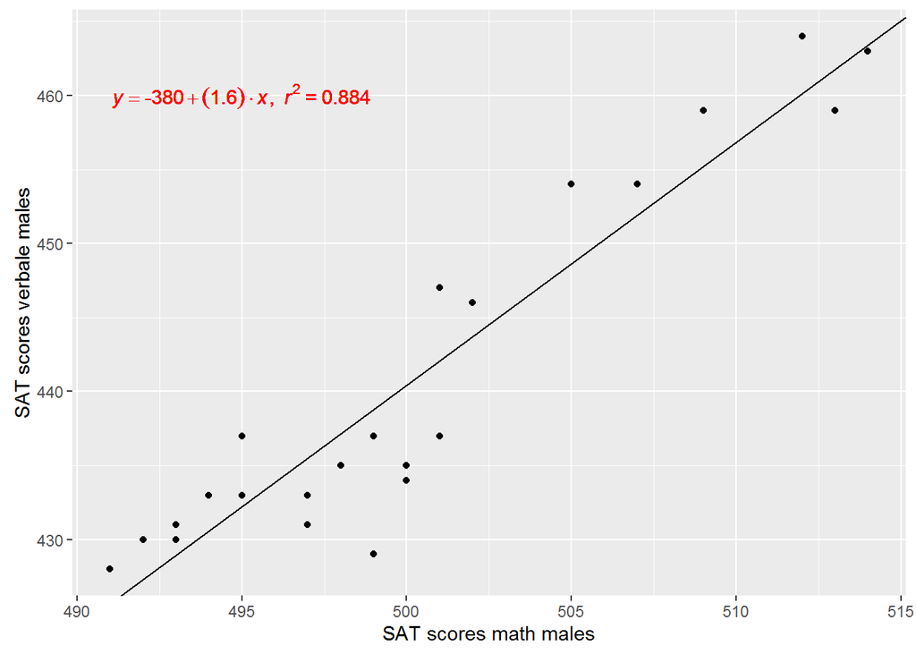

```r
p <- ggplot(maleFemaleSATscores, aes(x=MATH_MALES, y=VERBAL_MALES)) +
  geom_point() +
  geom_abline(slope = t$coefficients[2], intercept = t$coefficients[1]) +
  geom_text(x=495, y=460, label = lm_eqn(t), parse=TRUE, col="red") +
  xlab("SAT scores math males") +
  ylab("SAT scores verbale males")

p
```

```r
t <- lm(maleFemaleSATscores$VERBAL_FEMALES ~ maleFemaleSATscores$MATH_FEMALES)

coef(t)
```

```
##                      (Intercept) maleFemaleSATscores$MATH_FEMALES
##                      -336.059261                         1.698514
```

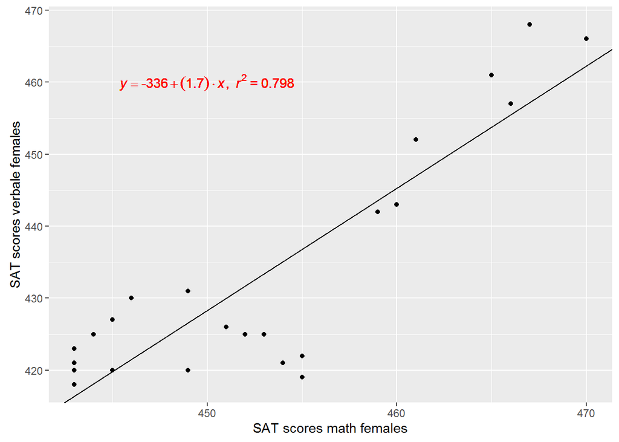

```r
p <- ggplot(maleFemaleSATscores, aes(x=MATH_FEMALES, y=VERBAL_FEMALES)) +
  geom_point() +
  geom_abline(slope = t$coefficients[2], intercept = t$coefficients[1]) +
  geom_text(x=450, y=460, label = lm_eqn(t), parse=TRUE, col="red") +
  xlab("SAT scores math females") +
  ylab("SAT scores verbale females")

p
```

#### d. Plot the female verbal SAT score against the male verbal SAT score. Sketch a regression line through the scatterpoints. What do you observe?

```r
t <- lm(maleFemaleSATscores$VERBAL_FEMALES ~ maleFemaleSATscores$VERBAL_MALES)

coef(t)
```

```
##                      (Intercept) maleFemaleSATscores$VERBAL_MALES
##                      -198.125848                         1.436426
```

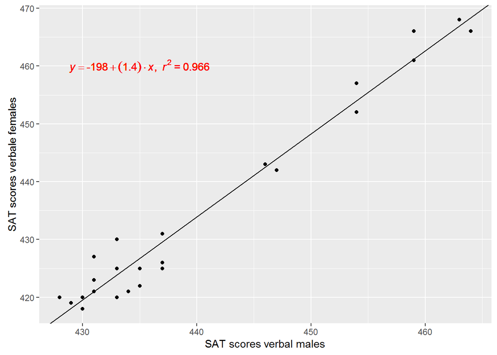

```r
p <- ggplot(maleFemaleSATscores, aes(x=VERBAL_MALES, y=VERBAL_FEMALES)) +
  geom_point() +
  geom_abline(slope = t$coefficients[2], intercept = t$coefficients[1]) +
  geom_text(x=435, y=460, label = lm_eqn(t), parse=TRUE, col="red") +
  xlab("SAT scores verbal males") +
  ylab("SAT scores verbale females")

p
```

A: Scores for males and females have moved in a linear fashion

Go to link Chapter2